# Exponentials and Logarithms

Autumn 2025

## It’s a learning curve

## Choose your groups

- Please divide into small groups for in-class tasks.
- Come up with a team name for your group

## In today’s session…

- Exponential functions
- Logarithmic functions
- uses
- Bachmann–Landau notation
- Activity

Today’s session is essentially the Stephen King book The Stand.

## Exponential Function

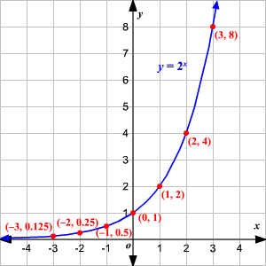

- Rate of change (acceleration) increases as \(x\) increases.

## \(y = 2^x\)

| x | y | difference |
| --- | --- | --- |
| 0 | 1 | - |
| 1 | 2 | 1 |
| 2 | 4 | 2 |
| 3 | 8 | 4 |
| 4 | 16 | 8 |
| 5 | 32 | 16 |
| 6 | 64 | 32 |
| 7 | 128 | 64 |
| 8 | 256 | 128 |
| 9 | 512 | 256 |
| 10 | 1024 | 512 |

## \(y = 3^x, y = 4^x, y = 5^x\)

| x | 3 | 4 | 5 |
| --- | --- | --- | --- |
| 0 | 1 | 1 | 1 |
| 1 | 3 | 4 | 5 |
| 2 | 9 | 16 | 25 |
| 3 | 27 | 64 | 125 |
| 4 | 81 | 256 | 625 |
| 5 | 243 | 1024 | 3125 |
| 6 | 729 | 4096 | 15625 |
| 7 | 2187 | 16384 | 78125 |
| 8 | 6561 | 65536 | 390625 |

[figure not shown]

## Captain Trips

- *Basic reproduction number*, \(R\)

  Number of new infections generated by one infected individual

  For example
  - \(R = 1\) means each infected person infect one other person
  - \(R = 3\) means each infected person infects 3 other people

| Disease | R |
| --- | --- |
| Nipah virus | 0.5 |
| Influenza (seasonal strains) | 1.3 |
| Ebola (2014 outbreak) | 1.8 |
| Influenza (1918) | 2 |
| Common cold (e.g., rhinovirus) | 2.5 |
| SARS | 3 |
| HIV/AIDS | 3.5 |
| Smallpox | 5 |
| Polio | 6 |
| Rubella | 6.5 |
| COVID-19 (Omicron variant) | 9.5 |
| Mumps | 11 |
| Chickenpox (varicella) | 11 |
| Measles | 14 |

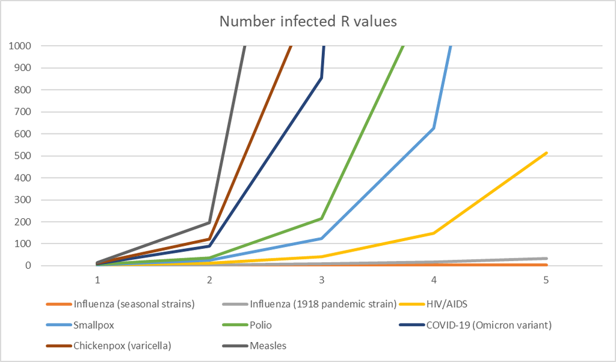

| Disease | R |
| --- | --- |
| Influenza (seasonal strains) | 1.3 |
| Influenza (1918 pandemic strain) | 2 |
| HIV/AIDS | 3.5 |
| Smallpox | 5 |
| Polio | 6 |
| COVID-19 (Omicron variant) | 9.5 |
| Chickenpox (varicella) | 11 |
| Measles | 14 |

## Naive forecasting

- The \(R\) number represents the exponential
- Mathematically correct but does not account for external factors
  - natural immunity
  - re-infection
  - population density
- \(R\) number alone is called a **naive forecasting**.

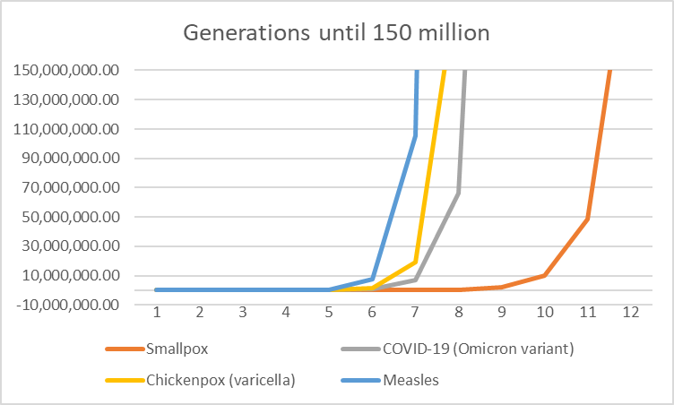

## Logarithmic Functions

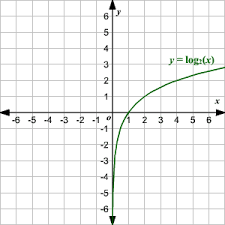

## \(\log_x(N)\) {.smaller}

| X | 2 | 5 | 10 |
| --- | --- | --- | --- |
| 1 | 0 | 0 | 0 |
| 2 | 1 | 0.430677 | 0.30103 |
| 3 | 1.584963 | 0.682606 | 0.477121 |
| 4 | 2 | 0.861353 | 0.60206 |
| 5 | 2.321928 | 1 | 0.69897 |
| 6 | 2.584963 | 1.113283 | 0.778151 |
| 7 | 2.807355 | 1.209062 | 0.845098 |
| 8 | 3 | 1.29203 | 0.90309 |
| 9 | 3.169925 | 1.365212 | 0.954243 |
| 10 | 3.321928 | 1.430677 | 1 |

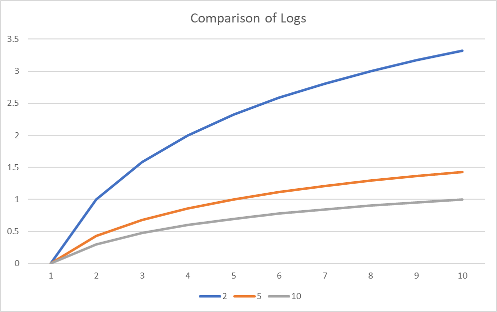

## Logarithms are the inverse of exponentials

- We have \(3^4 = 81\)

  (in words, 3 raised to the power of 4 equals 81)
- and \(\log_3(81) = 4\)

  (in words, log base 3 of 81 equals 4)

## Logarithms are the inverse of exponentials

- To compute the \(\log_b\) of a number \(N\),
  - we write \(\log_b(N) = x\),
  - equivalent to \(b^x = N\),
  - we find the power \(x\) the base \(b\) is raised to in order to produce \(N\).
- \(\log_3(81) = 4\) because
- \(3 \cdot 3 \cdot 3 \cdot 3 = 3^4 = 81\)

## The Richter Scale

- Severity of earthquakes are measured by the height (amplitude) of waves recorded by a seismograph.
- Richter scale is logarithmic

  \(\log_10(A)\)
- The next number on the Richter scale represents a magnitude **10 times** greater than that of the previous.

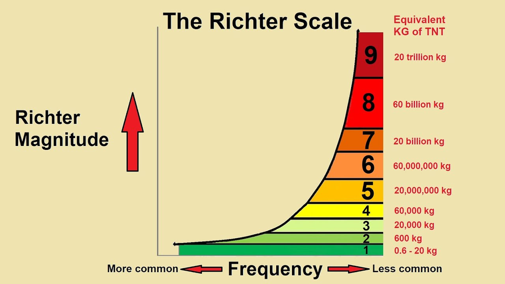

- Logs are useful for compressing scales on graphs

## Trash Can Man and the oil tanker

- An explosion pushes matter (typically gas) out of the way.
- Shockwaves (loosely speaking) follow the inverse square law:

  \(\text{intensity} = \dfrac{1}{\text{distance}^2}\),
- and the first law of thermodynamics

  \(\text{Output energy} = \text{input energy} - \text{Work done}\).
- The shockwave can be followed by heat and negative pressure waves

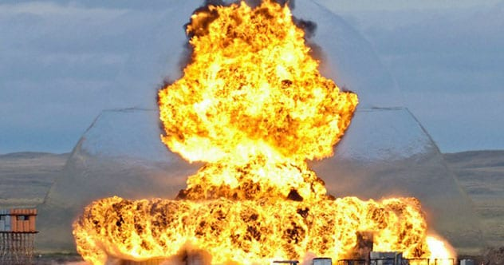

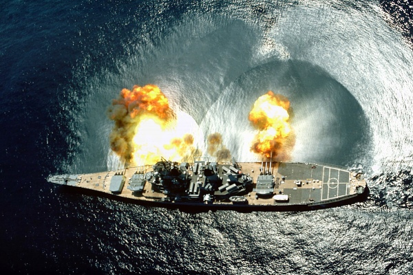

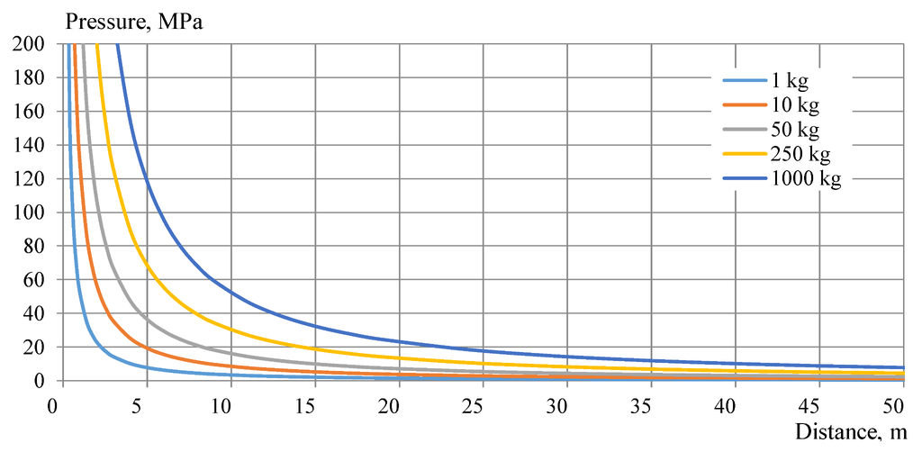

## Explosion fatality rates

[output not shown]

- Calculate the pressure wave drop-off
- Calculate fatality rates based on distance from epicentre
- Assign fatality zones
- Other calculations can take heat and negative pressure into account

## Roy Kelton Orbson

- April 23 1936 to December 6 1986
- Famous American soul singer
- Popular in the early 60s and late 70s
- Hits isclude
  - You got it
  - Crying
  - Only the lonely
- Known as “The Big O”

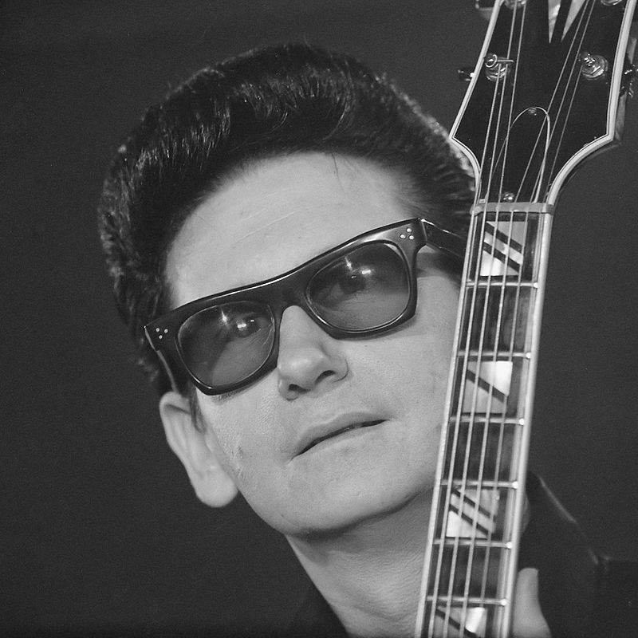

Roy Orbson, 1965

## Big O Notation

### Using maths to analyse the efficiency of your code.

## Ordnung Notation

- Expresses time / resources needed to perform a computation
- We can analyse a task based on the “size” of its input
- Allows us to compare different methods for completing the same task
- We represent the size of the input as \(n\), then
- we write \(\mathcal{O} ( \text{expression in terms of }n )\)

## Bubble sort

Complexity of \(\mathcal{O}(n^2)\)

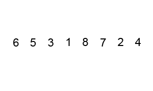

See [https://www.sortvisualizer.com/bubblesort/]

## Quicksort

- Splits list in two (usually equal size)
- Numbers compared against *pivot* element separating the 2 sublists.
- Numbers are placed either *below* or *above* the pivot.
- Process is repeated with smaller and smaller sublists (divide an conquer)

## Quicksort

Complexity \(\mathcal{O} (n \log n)\)

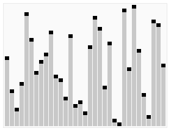

See [https://www.sortvisualizer.com/]

## Best and worst sort

## Hold up!

- What do I mean by *“best”*?
- Usually: fewest computations

  (minimise the number of comparisons)
- Sometimes: consumes least amount of memory
- Occasionally: something else

## Ordnung Notation

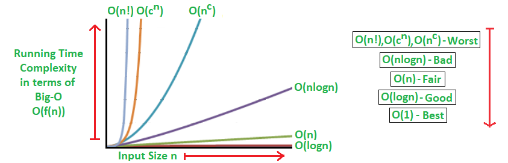

## Population Calculations

- Today’s lab: calculate population growth over the next 100 years
- **The Free Zone** - initial population 20
- **Las Vegas** - initial population 50,000
- Start by making some assumptions about birth and death rates
- Plot how population changes over time
- Next, add other factors, e.g. migration, pandemics, …

## Pandemic Calculation

- Now calculate how a pandemic would move through the populations of The Free Zone and Las Vegas after 100 years of population growth
  - What are limiting factors?
  - What are accellerating factors?